# Rusundersøkelse 2025

## TobPrSn1

*Hvor mange pris/porsjoner snus bruker du gjennomsnittlig pr. dag?*

| Feature | Result |
| --- | --- |
| Variable type | integer |
| Number of missing obs. | 3935 (85.28 %) |
| Number of unique values | 27 |
| Median | 10 |
| 1st and 3rd quartiles | 7; 15 |
| Min. and max. | 1; 99 |

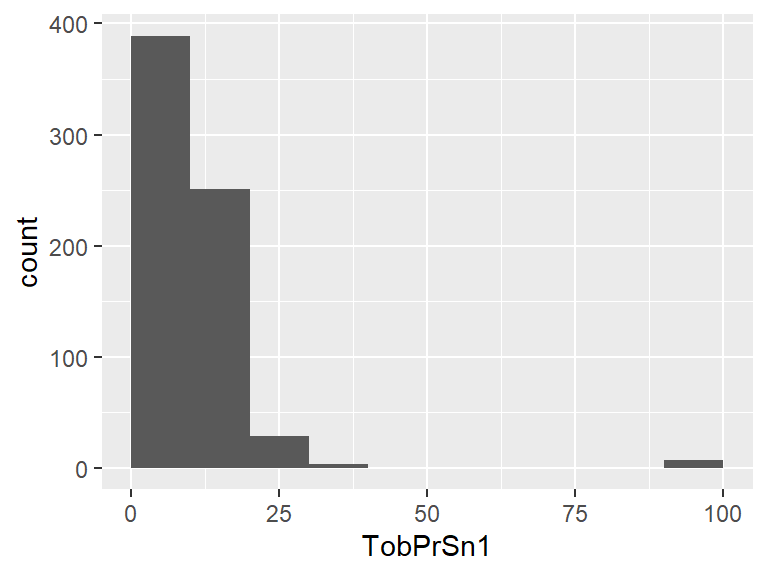

- The following suspected missing value codes enter as regular values: "99".
- Note that the following possible outlier values were detected: "1", "2", "99".

## TobPrSn2

*Hvor mange pris/porsjoner snus bruker du gjennomsnittlig pr. uke?*

| Feature | Result |
| --- | --- |
| Variable type | integer |
| Number of missing obs. | 4431 (96.03 %) |
| Number of unique values | 29 |
| Median | 8 |
| 1st and 3rd quartiles | 1; 20 |
| Min. and max. | 0; 99 |

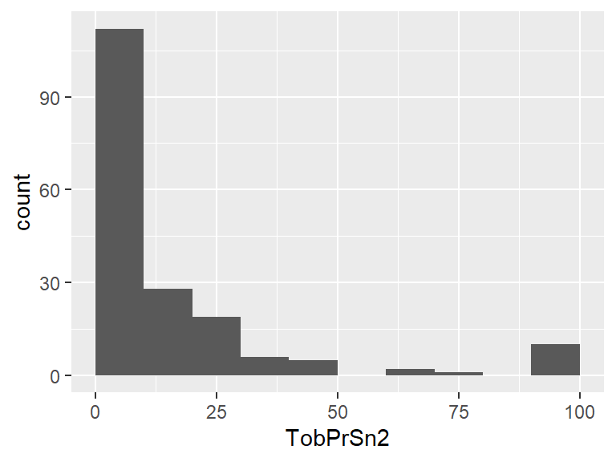

## Tob66

*Hva slags snus bruker du hovedsakelig, porsjonssnus eller løssnus?*

| Feature | Result |
| --- | --- |
| Variable type | factor |
| Number of missing obs. | 3752 (81.32 %) |
| Number of unique values | 7 |
| Mode | “2” |
| Reference category | 1 |

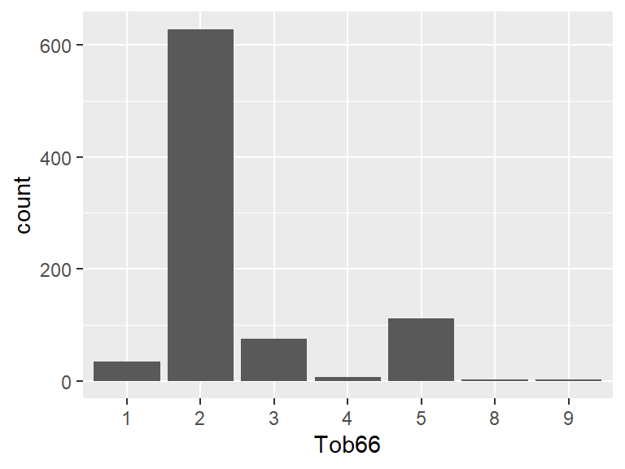

- The following suspected missing value codes enter as regular values: "8", "9".
- Note that the following levels have at most five observations: "8", "9".

## Tob68

*Hvor gammel var du da du begynte å bruke snus regelmessig? Alder:*

| Feature | Result |
| --- | --- |
| Variable type | integer |
| Number of missing obs. | 3752 (81.32 %) |
| Number of unique values | 55 |
| Median | 20 |
| 1st and 3rd quartiles | 17; 33 |
| Min. and max. | 9; 99 |

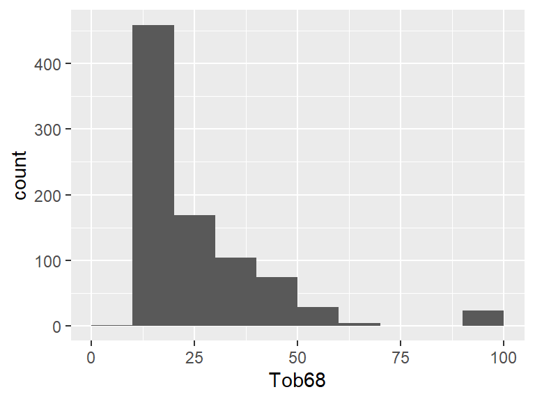

- Note that the following possible outlier values were detected: "9", "12", "13", "14", "15".

## Tob69

*Hva begynte du med først, snus eller sigaretter*

| Feature | Result |
| --- | --- |
| Variable type | factor |
| Number of missing obs. | 3770 (81.71 %) |
| Number of unique values | 5 |
| Mode | “1” |
| Reference category | 1 |

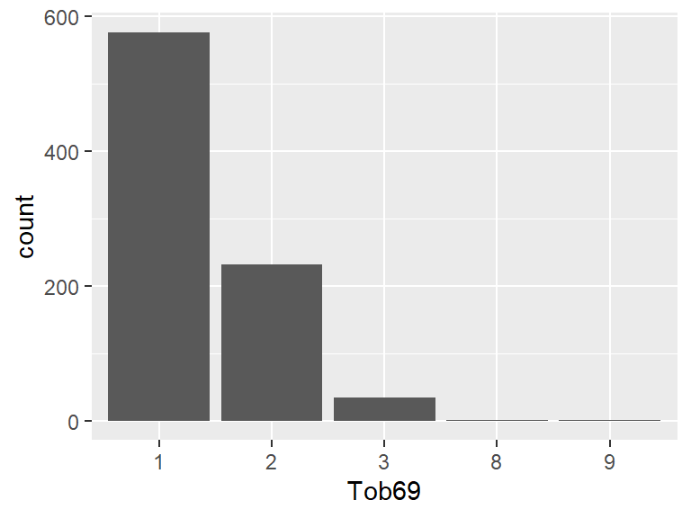

- The following suspected missing value codes enter as regular values: "8", "9".
- Note that the following levels have at most five observations: "8", "9".

## Tob69b

*Bruker du noen former for nikotinerstatningsprodukter nå*

| Feature | Result |
| --- | --- |
| Variable type | factor |
| Number of missing obs. | 1985 (43.02 %) |
| Number of unique values | 4 |
| Mode | “2” |
| Reference category | 1 |

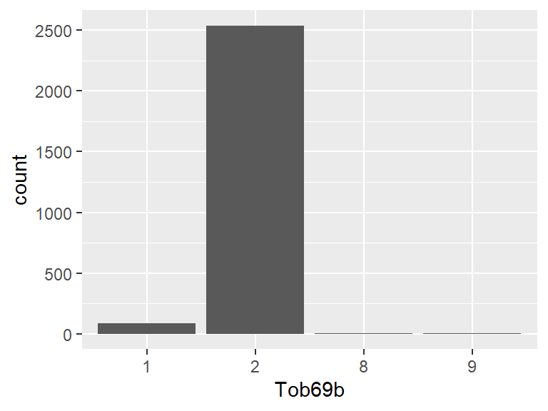

- The following suspected missing value codes enter as regular values: "8", "9".
- Note that the following levels have at most five observations: "8", "9".

## Tob71

*Vurderer du seriøst å slutte å bruke snus de neste 6 månedene*

| Feature | Result |
| --- | --- |
| Variable type | factor |
| Number of missing obs. | 3752 (81.32 %) |
| Number of unique values | 4 |
| Mode | “2” |
| Reference category | 1 |

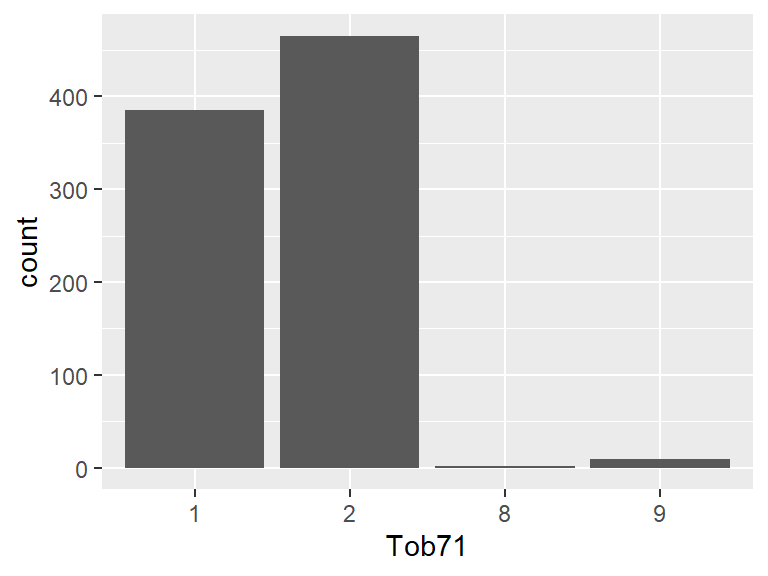

- The following suspected missing value codes enter as regular values: "8", "9".
- Note that the following levels have at most five observations: "8".

## tobsluttsn1

*Har du noen gang prøvd å slutte med snus?*

| Feature | Result |
| --- | --- |
| Variable type | factor |
| Number of missing obs. | 3752 (81.32 %) |
| Number of unique values | 5 |
| Mode | “3” |
| Reference category | 1 |

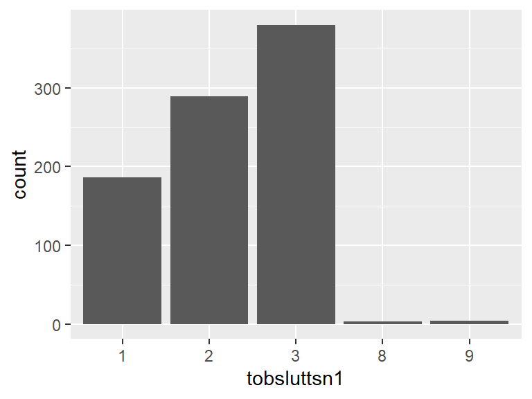

- The following suspected missing value codes enter as regular values: "8", "9".
- Note that the following levels have at most five observations: "8", "9".

## tobsluttsn2

*Hvilket år sluttet du med snus?*

| Feature | Result |
| --- | --- |
| Variable type | integer |
| Number of missing obs. | 4245 (92 %) |
| Number of unique values | 40 |
| Median | 2020 |
| 1st and 3rd quartiles | 2015; 2023 |
| Min. and max. | 1968; 9999 |

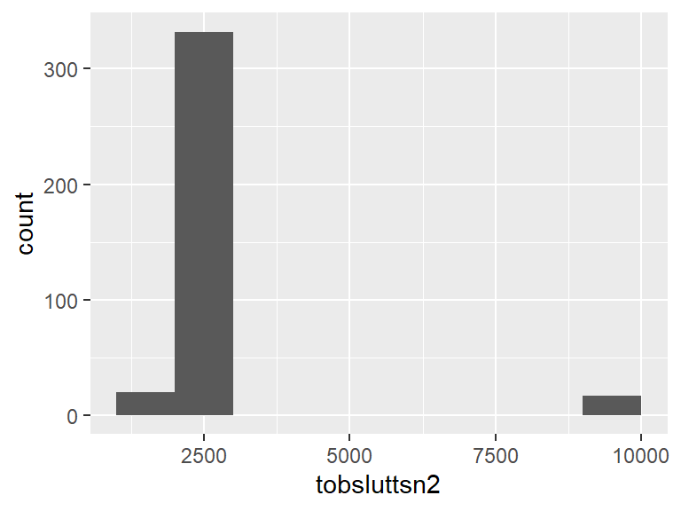

- Note that the following possible outlier values were detected: "1968", "1977", "1980", "1982", "1984", "1986", "1988", "9998", "9999".

## Drukket1

*Har drukket alkohol siste 12 mnd*

| Feature | Result |
| --- | --- |
| Variable type | factor |
| Number of missing obs. | 0 (0 %) |
| Number of unique values | 3 |
| Mode | “1” |
| Reference category | 1 |

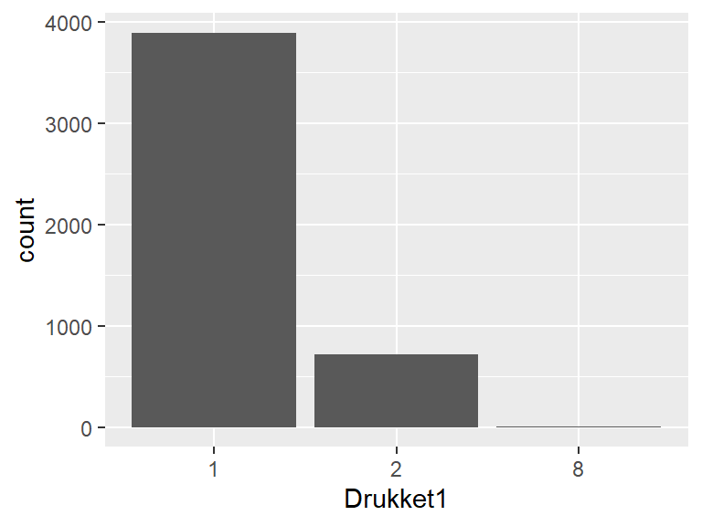

- The following suspected missing value codes enter as regular values: "8".
- Note that the following levels have at most five observations: "8".

## Drukk1b

*Har du noen gang drukket alkohol*

| Feature | Result |
| --- | --- |
| Variable type | factor |
| Number of missing obs. | 3897 (84.46 %) |
| Number of unique values | 4 |
| Mode | “1” |
| Reference category | 1 |

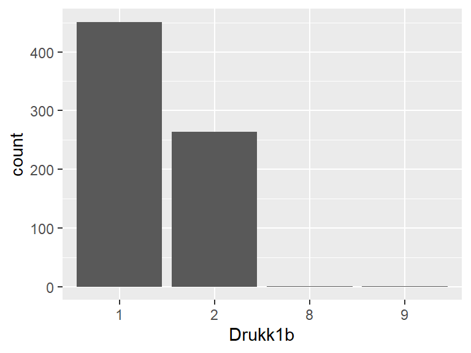

- The following suspected missing value codes enter as regular values: "8", "9".
- Note that the following levels have at most five observations: "8", "9".

## Drukket2

*Hvor ofte drukket alkohol siste 12 mnd*

| Feature | Result |
| --- | --- |
| Variable type | factor |
| Number of missing obs. | 722 (15.65 %) |
| Number of unique values | 6 |
| Mode | “3” |
| Reference category | 1 |

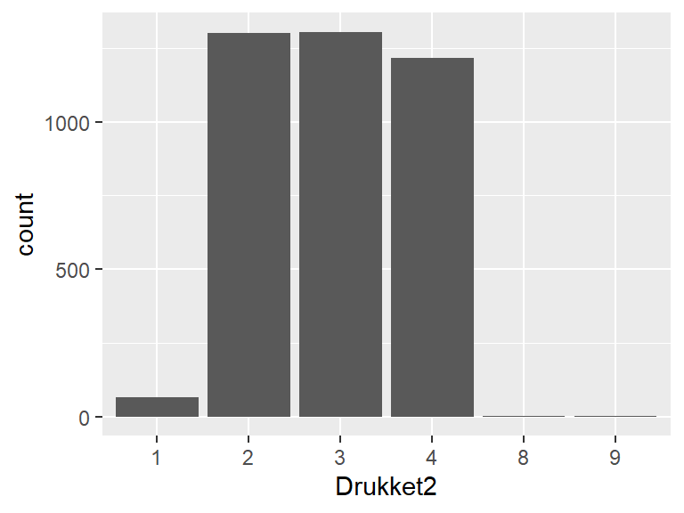

- The following suspected missing value codes enter as regular values: "8", "9".
- Note that the following levels have at most five observations: "8", "9".

## Drukk2a

*Drukket alkohol ukentlig*

| Feature | Result |
| --- | --- |
| Variable type | factor |
| Number of missing obs. | 3314 (71.82 %) |
| Number of unique values | 5 |
| Mode | “3” |
| Reference category | 1 |

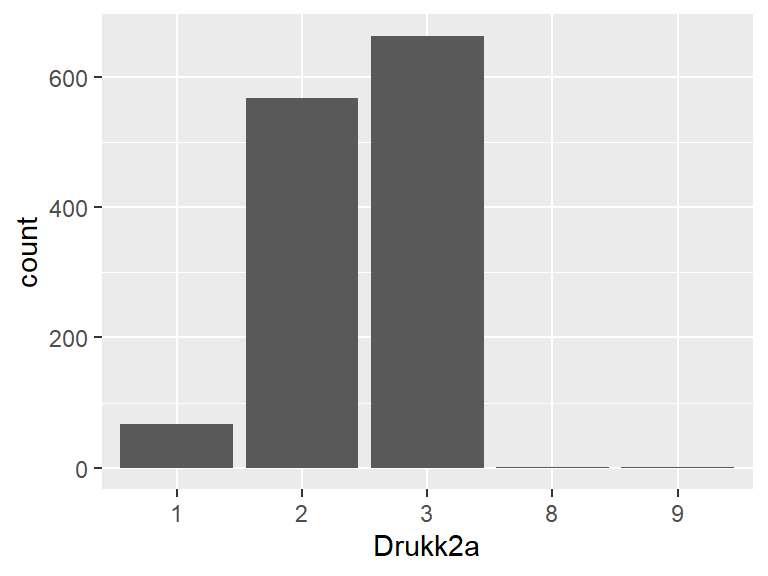

- The following suspected missing value codes enter as regular values: "8", "9".
- Note that the following levels have at most five observations: "8", "9".

## Drukk2b

*Antall dager drukket alkohol pr mnd siste 12 mnd*

| Feature | Result |
| --- | --- |
| Variable type | factor |
| Number of missing obs. | 3309 (71.72 %) |
| Number of unique values | 4 |
| Mode | “2” |
| Reference category | 1 |

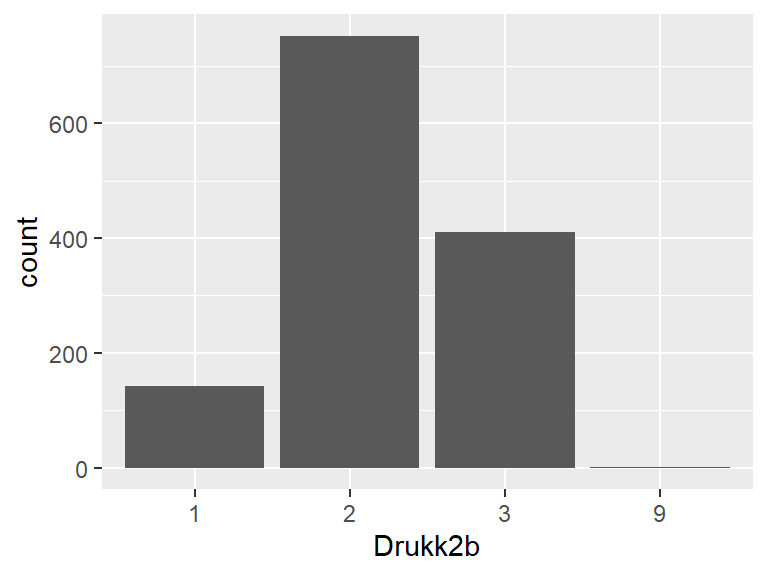

- The following suspected missing value codes enter as regular values: "9".
- Note that the following levels have at most five observations: "9".

## Drukk2c

*Drukket alkohol få dager/en dag siste 12 mnd*

| Feature | Result |
| --- | --- |
| Variable type | factor |
| Number of missing obs. | 3396 (73.6 %) |
| Number of unique values | 5 |
| Mode | “1” |
| Reference category | 1 |

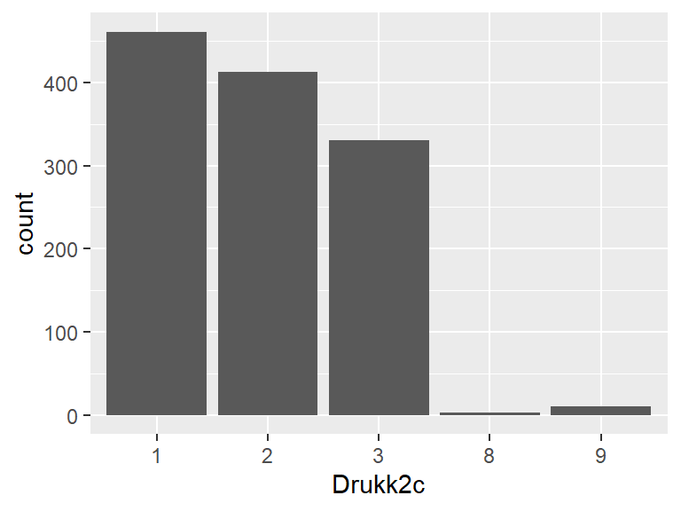

- The following suspected missing value codes enter as regular values: "8", "9".
- Note that the following levels have at most five observations: "8".

## Drukket3

*Har drukket alkohol siste 4 uker*

| Feature | Result |
| --- | --- |
| Variable type | factor |
| Number of missing obs. | 722 (15.65 %) |
| Number of unique values | 4 |
| Mode | “1” |
| Reference category | 1 |

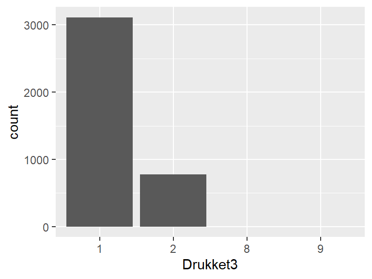

- The following suspected missing value codes enter as regular values: "8", "9".
- Note that the following levels have at most five observations: "8", "9".

## Type1

*Har drukket øl siste 4 uker*

| Feature | Result |
| --- | --- |
| Variable type | factor |
| Number of missing obs. | 1501 (32.53 %) |
| Number of unique values | 3 |
| Mode | “1” |
| Reference category | 1 |

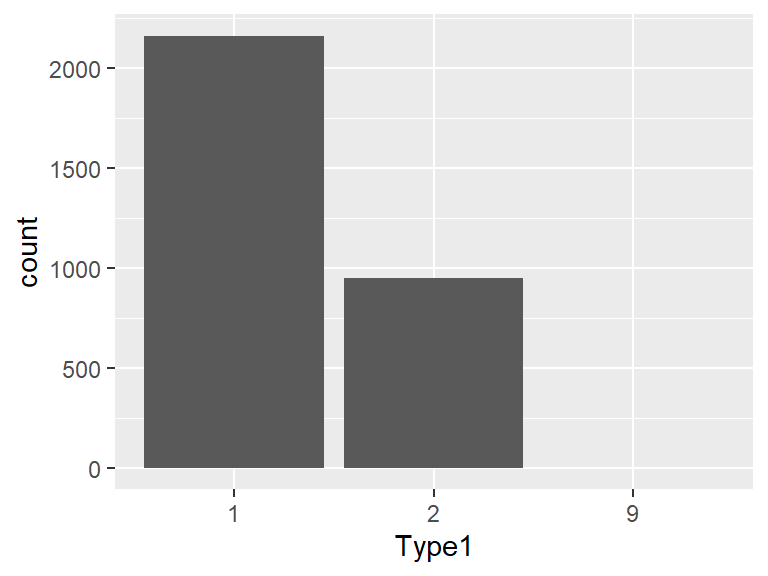

- The following suspected missing value codes enter as regular values: "9".
- Note that the following levels have at most five observations: "9".

## Type2

*Har drukket vin siste 4 uker*

| Feature | Result |
| --- | --- |
| Variable type | factor |
| Number of missing obs. | 1501 (32.53 %) |
| Number of unique values | 2 |
| Mode | “1” |
| Reference category | 1 |

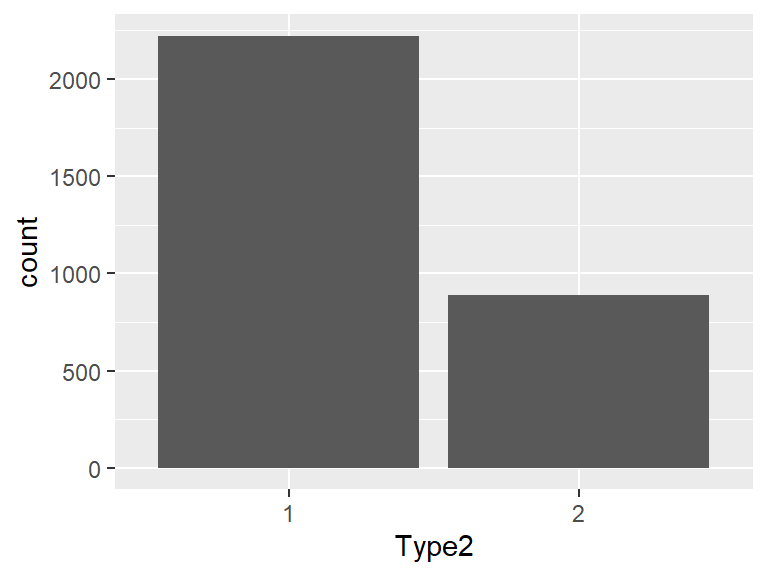

## Type3

*Har drukket brennevin siste 4 uker*

| Feature | Result |
| --- | --- |
| Variable type | factor |
| Number of missing obs. | 1501 (32.53 %) |
| Number of unique values | 2 |
| Mode | “2” |
| Reference category | 1 |

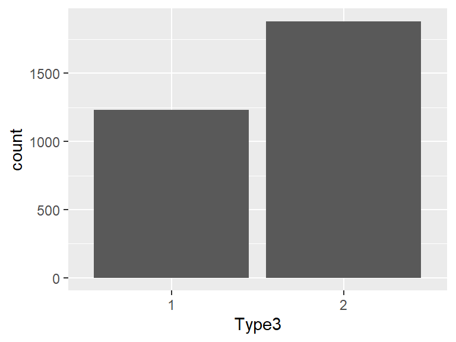

## Type4

*Har drukket rusbrus/cider siste 4 uker*

| Feature | Result |
| --- | --- |
| Variable type | factor |
| Number of missing obs. | 1501 (32.53 %) |
| Number of unique values | 3 |
| Mode | “2” |
| Reference category | 1 |

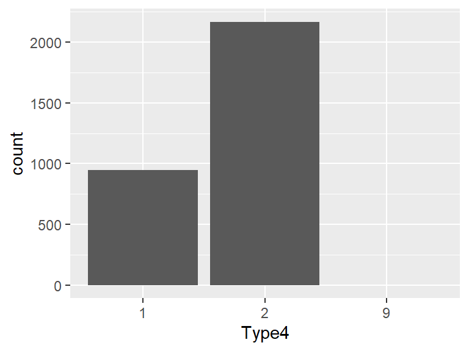

- The following suspected missing value codes enter as regular values: "9".
- Note that the following levels have at most five observations: "9".

## Type1a

*Hvor ofte drukket øl siste 4 uker?*

| Feature | Result |
| --- | --- |
| Variable type | factor |
| Number of missing obs. | 2452 (53.14 %) |
| Number of unique values | 5 |
| Mode | “3” |
| Reference category | 1 |

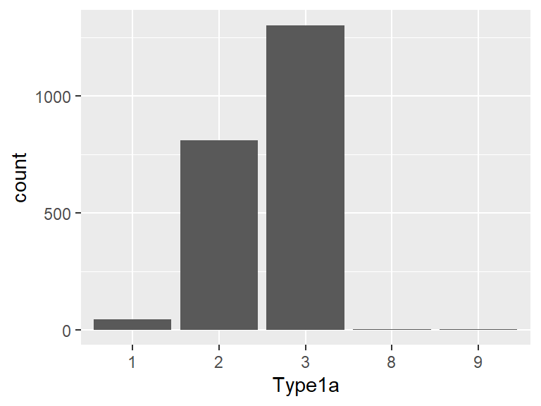

- The following suspected missing value codes enter as regular values: "8", "9".
- Note that the following levels have at most five observations: "8", "9".

## Typ1a_uk

*Ukentlig: Ant dager i uken drukket øl siste 4 uker?*

| Feature | Result |
| --- | --- |
| Variable type | factor |
| Number of missing obs. | 3802 (82.4 %) |
| Number of unique values | 4 |
| Mode | “3” |
| Reference category | 1 |

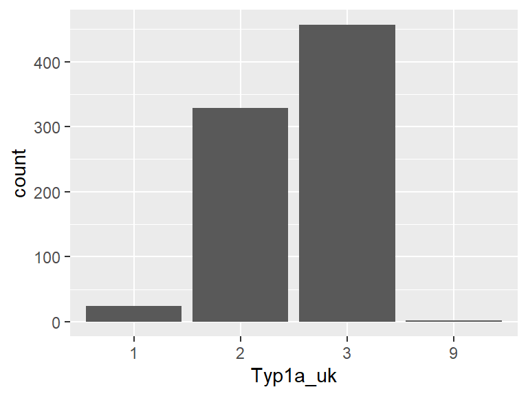

- The following suspected missing value codes enter as regular values: "9".
- Note that the following levels have at most five observations: "9".

## Typ1a_mn

*Månedlig: Ant dager i uken drukket øl siste 4 uker?*

| Feature | Result |
| --- | --- |
| Variable type | factor |
| Number of missing obs. | 3311 (71.76 %) |
| Number of unique values | 5 |
| Mode | “3” |
| Reference category | 1 |

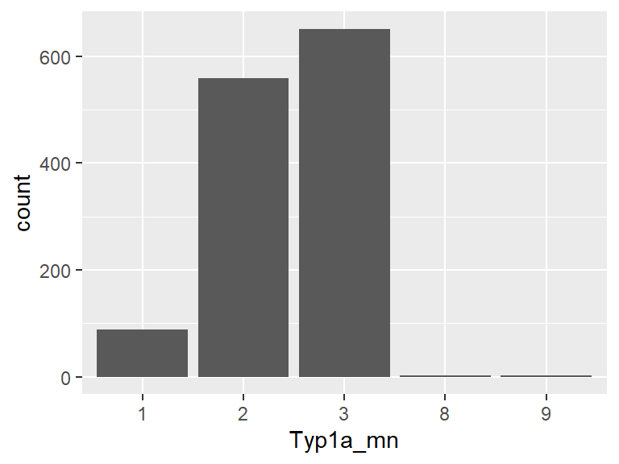

- The following suspected missing value codes enter as regular values: "8", "9".
- Note that the following levels have at most five observations: "8", "9".

## Type1b_a

*Ukentlig: Drukket 0,33 liter øl siste 4 uker*

| Feature | Result |
| --- | --- |
| Variable type | factor |
| Number of missing obs. | 3758 (81.45 %) |
| Number of unique values | 3 |
| Mode | “2” |
| Reference category | 1 |

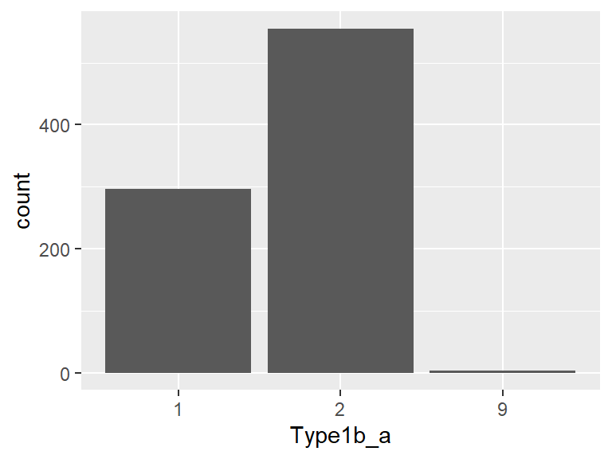

- The following suspected missing value codes enter as regular values: "9".
- Note that the following levels have at most five observations: "9".

## Type1b_b

*Ukentlig: Drukket 0,5 liter øl siste 4 uker*

| Feature | Result |
| --- | --- |
| Variable type | factor |
| Number of missing obs. | 3758 (81.45 %) |
| Number of unique values | 3 |
| Mode | “1” |
| Reference category | 1 |

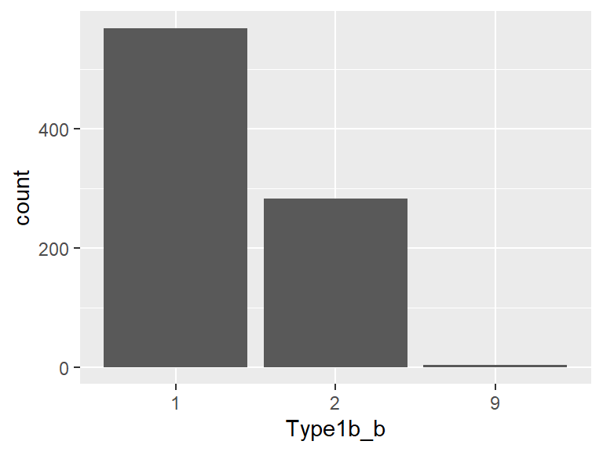

- The following suspected missing value codes enter as regular values: "9".
- Note that the following levels have at most five observations: "9".

## Type1b_1

*Ukentlig: Gjennomsnitt ant 0,33 l øl drukket siste 4 uker?*

| Feature | Result |
| --- | --- |
| Variable type | numeric |
| Number of missing obs. | 4317 (93.56 %) |
| Number of unique values | 22 |
| Median | 3 |
| 1st and 3rd quartiles | 2; 5 |
| Min. and max. | 0.5; 99999 |

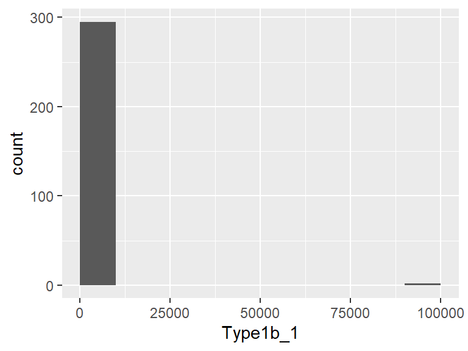

- The following suspected missing value codes enter as regular values: "99999".
- Note that the following possible outlier values were detected: "0.5", "0.6", "24", "30", "50", "99999".

## Type1b_2

*Ukentlig: Gjennomsnitt ant 0,5 l øl drukket siste 4 uker?*

| Feature | Result |
| --- | --- |
| Variable type | numeric |
| Number of missing obs. | 4045 (87.67 %) |
| Number of unique values | 32 |
| Median | 4 |
| 1st and 3rd quartiles | 2; 6 |
| Min. and max. | 0.1; 99999 |

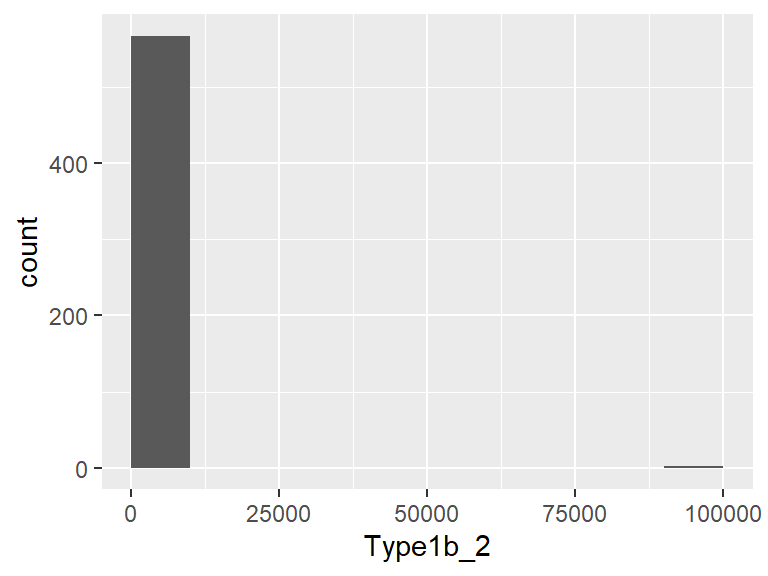

- The following suspected missing value codes enter as regular values: "99999".
- Note that the following possible outlier values were detected: "0.1", "24", "25", "30", "35", "37", "40", "45", "50", "56", "99999".

## Type1c_a

*Månedlig: Drukket 0,33 liter øl siste 4 uker*

| Feature | Result |
| --- | --- |
| Variable type | factor |
| Number of missing obs. | 3311 (71.76 %) |
| Number of unique values | 4 |
| Mode | “1” |
| Reference category | 1 |

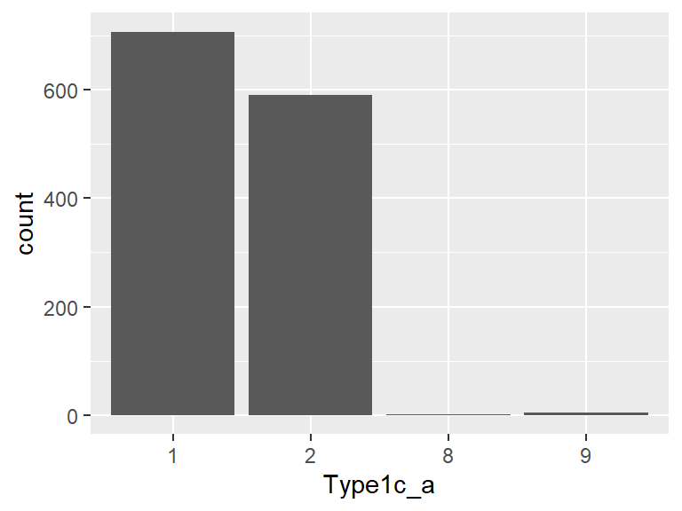

- The following suspected missing value codes enter as regular values: "8", "9".
- Note that the following levels have at most five observations: "8", "9".

## Type1c_b

*Månedlig: Drukket 0,5 liter øl siste 4 uker*

| Feature | Result |
| --- | --- |
| Variable type | factor |
| Number of missing obs. | 3311 (71.76 %) |
| Number of unique values | 4 |
| Mode | “2” |
| Reference category | 1 |

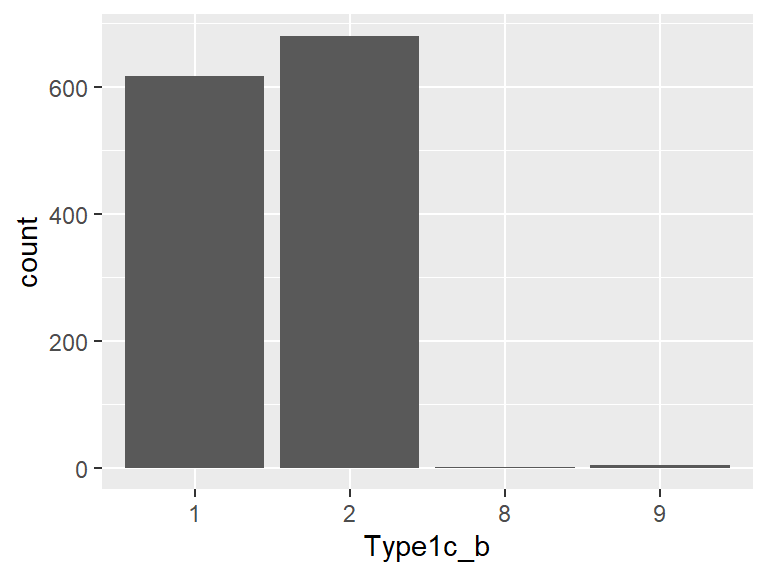

- The following suspected missing value codes enter as regular values: "8", "9".
- Note that the following levels have at most five observations: "8", "9".

## Type1c_1

*Månedlig: Antall 0,33 l øl drukket siste 4 uker?*

| Feature | Result |
| --- | --- |
| Variable type | numeric |
| Number of missing obs. | 3907 (84.68 %) |
| Number of unique values | 24 |
| Median | 3 |
| 1st and 3rd quartiles | 2; 5 |
| Min. and max. | 0.5; 99999 |

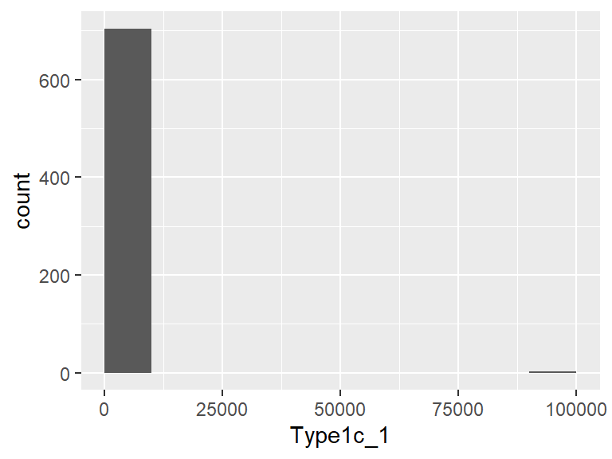

- Note that the following possible outlier values were detected: "0.5", "0.6", "1", "24", "35", "40", "99998", "99999".

## Type1c_2

*Månedlig: Antall 0,5 l øl drukket siste 4 uker?*

| Feature | Result |
| --- | --- |
| Variable type | numeric |
| Number of missing obs. | 3997 (86.63 %) |
| Number of unique values | 28 |
| Median | 5 |
| 1st and 3rd quartiles | 2; 8 |
| Min. and max. | 0.1; 99999 |

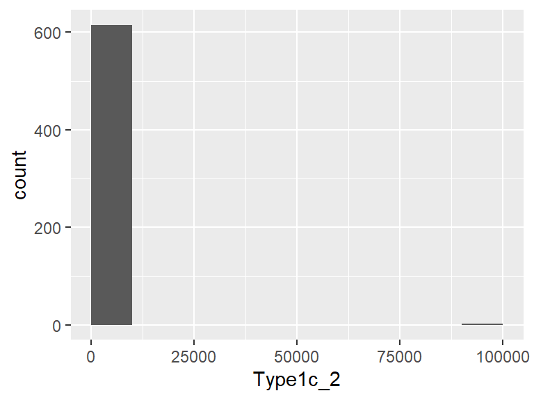

- The following suspected missing value codes enter as regular values: "99999".
- Note that the following possible outlier values were detected: "25", "30", "32", "35", "40", "60", "99999".

## Type2a

*Hvor ofte drukket vin siste 4 uker?*

| Feature | Result |
| --- | --- |
| Variable type | factor |
| Number of missing obs. | 2392 (51.84 %) |
| Number of unique values | 5 |
| Mode | “3” |
| Reference category | 1 |

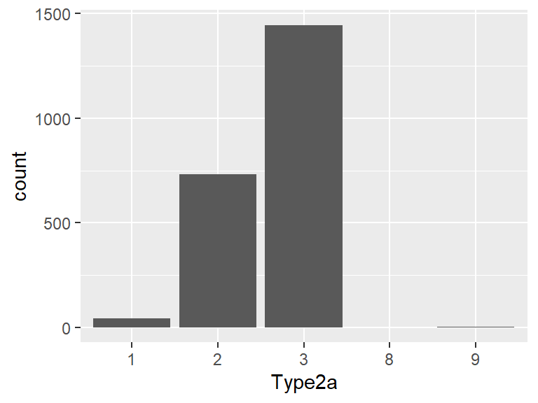

- The following suspected missing value codes enter as regular values: "8", "9".
- Note that the following levels have at most five observations: "8", "9".

## Typ2a_uk

*Ukentlig: Ant dager i uken drukket vin siste 4 uker?*

| Feature | Result |
| --- | --- |
| Variable type | factor |
| Number of missing obs. | 3883 (84.16 %) |
| Number of unique values | 5 |
| Mode | “3” |
| Reference category | 1 |

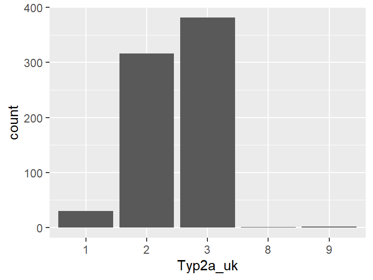

- The following suspected missing value codes enter as regular values: "8", "9".
- Note that the following levels have at most five observations: "8", "9".

## Typ2a_mn

*Månedlig: Ant dager i uken drukket vin siste 4 uker?*

| Feature | Result |
| --- | --- |
| Variable type | factor |
| Number of missing obs. | 3169 (68.68 %) |
| Number of unique values | 5 |
| Mode | “3” |
| Reference category | 1 |

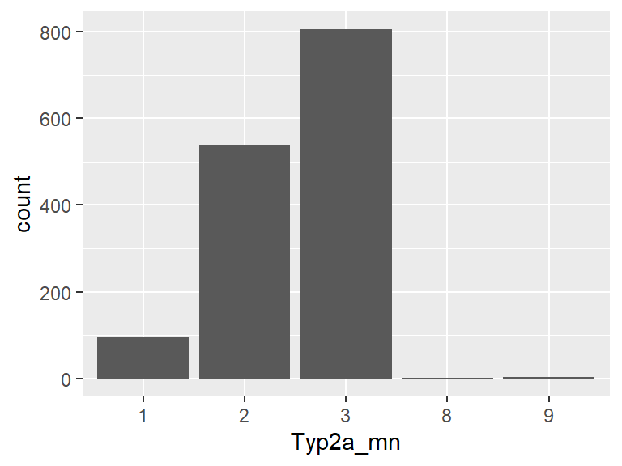

- The following suspected missing value codes enter as regular values: "8", "9".
- Note that the following levels have at most five observations: "8", "9".

## Type2b_a

*Ukentlig: Drukket glass vin siste 4 uker*

| Feature | Result |
| --- | --- |
| Variable type | factor |
| Number of missing obs. | 3841 (83.25 %) |
| Number of unique values | 4 |
| Mode | “1” |
| Reference category | 1 |

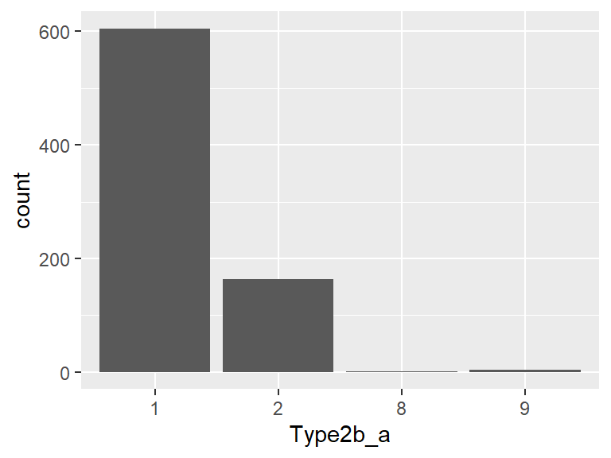

- The following suspected missing value codes enter as regular values: "8", "9".
- Note that the following levels have at most five observations: "8", "9".

## Type2b_b

*Ukentlig: Drukket flasker vin siste 4 uker*

| Feature | Result |
| --- | --- |
| Variable type | factor |
| Number of missing obs. | 3841 (83.25 %) |
| Number of unique values | 4 |
| Mode | “2” |
| Reference category | 1 |

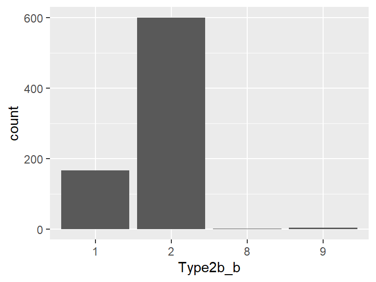

- The following suspected missing value codes enter as regular values: "8", "9".
- Note that the following levels have at most five observations: "8", "9".

## Type2b_1

*Ukentlig: Gjennomsnitt antall glass vin drukket siste 4 uker?*

| Feature | Result |
| --- | --- |
| Variable type | numeric |
| Number of missing obs. | 4009 (86.89 %) |
| Number of unique values | 24 |
| Median | 3 |
| 1st and 3rd quartiles | 2; 5 |
| Min. and max. | 0.5; 56 |

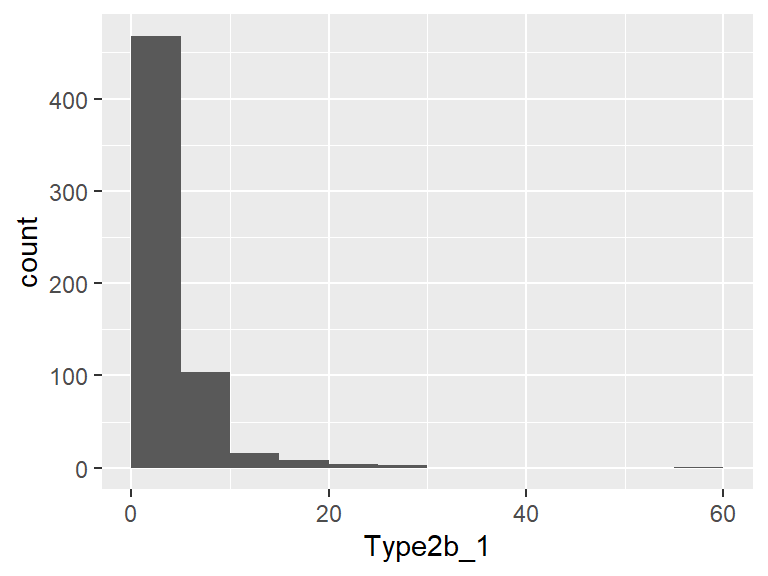

- Note that the following possible outlier values were detected: "0.5", "20", "21", "24", "25", "28", "30", "56".

## Type2b_2

*Ukentlig: Gjennomsnitt antall flasker vin drukket siste 4 uker?*

| Feature | Result |
| --- | --- |
| Variable type | numeric |
| Number of missing obs. | 4447 (96.38 %) |
| Number of unique values | 14 |
| Median | 1.5 |
| 1st and 3rd quartiles | 1; 3 |
| Min. and max. | 0.2; 16 |

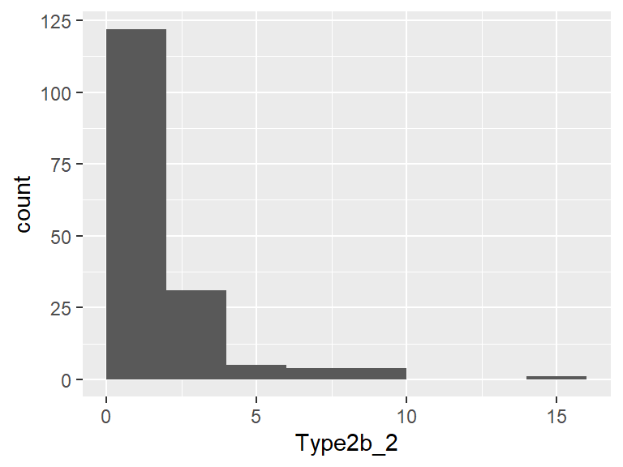

- Note that the following possible outlier values were detected: "0.2", "0.3", "0.5".

## Type2c_a

*Månedlig: Drukket glass vin siste 4 uker*

| Feature | Result |
| --- | --- |
| Variable type | factor |
| Number of missing obs. | 3169 (68.68 %) |
| Number of unique values | 3 |
| Mode | “1” |
| Reference category | 1 |

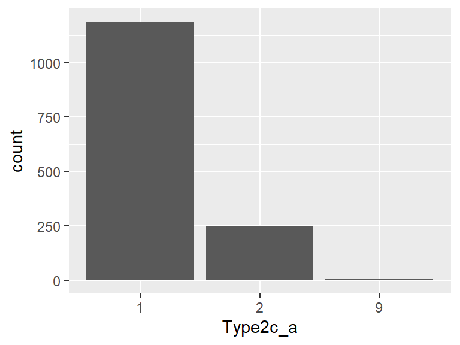

- The following suspected missing value codes enter as regular values: "9".

## Type2c_b

*Månedlig: Drukket flasker vin siste 4 uker*

| Feature | Result |
| --- | --- |
| Variable type | factor |
| Number of missing obs. | 3169 (68.68 %) |
| Number of unique values | 3 |
| Mode | “2” |
| Reference category | 1 |

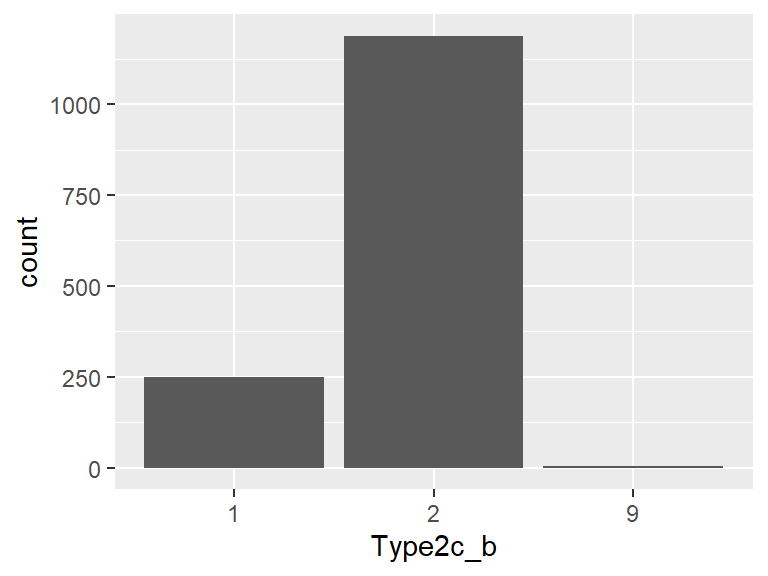

- The following suspected missing value codes enter as regular values: "9".

## Type2c_1

*Månedlig: Antall glass vin drukket siste 4 uker?*

| Feature | Result |
| --- | --- |
| Variable type | numeric |
| Number of missing obs. | 3424 (74.21 %) |
| Number of unique values | 23 |
| Median | 3 |
| 1st and 3rd quartiles | 2; 5 |
| Min. and max. | 0.1; 99999 |

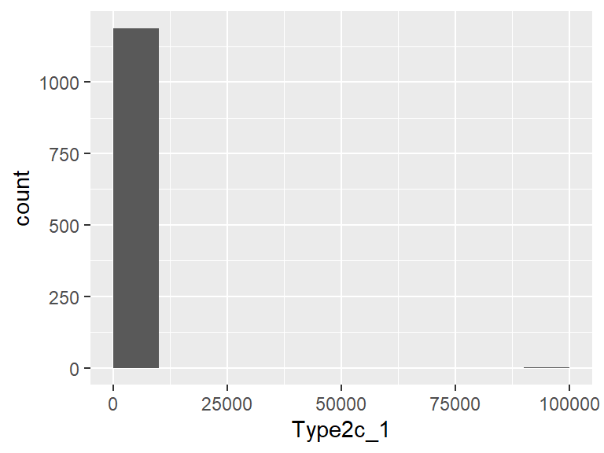

- The following suspected missing value codes enter as regular values: "99999".
- Note that the following possible outlier values were detected: "0.1", "0.5", "17.5", "20", "21", "22", "24", "25", "99999".

## Type2c_2

*Månedlig: Antall flasker vin drukket siste 4 uker?*

| Feature | Result |
| --- | --- |
| Variable type | numeric |
| Number of missing obs. | 4363 (94.56 %) |
| Number of unique values | 13 |
| Median | 1.5 |
| 1st and 3rd quartiles | 1; 2 |
| Min. and max. | 0.1; 99999 |

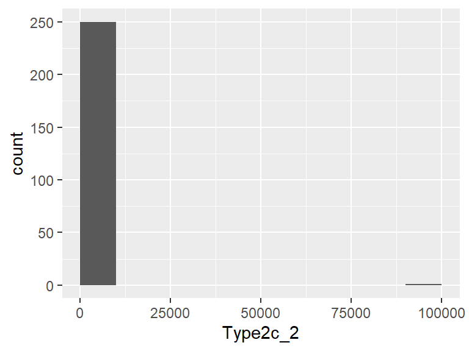

- The following suspected missing value codes enter as regular values: "99999".
- Note that the following possible outlier values were detected: "4", "5", "6", "12", "99999".

## Type3a

*Hvor ofte drukket brennevin siste 4 uker?*

| Feature | Result |
| --- | --- |
| Variable type | factor |
| Number of missing obs. | 3383 (73.32 %) |
| Number of unique values | 4 |
| Mode | “3” |
| Reference category | 1 |

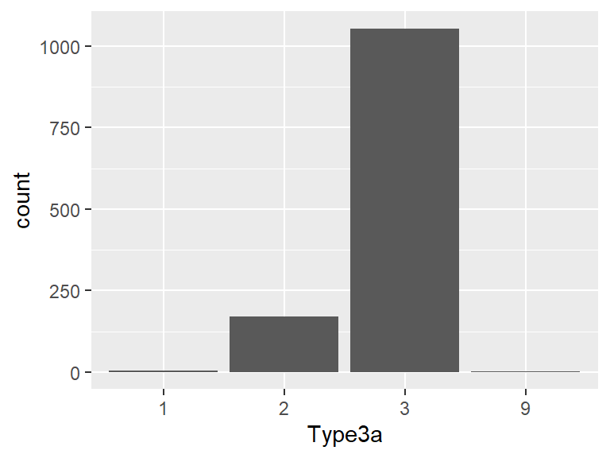

- The following suspected missing value codes enter as regular values: "9".
- Note that the following levels have at most five observations: "1", "9".

## Typ3a_uk

*Ukentlig: Ant dager i uken drukket brennevin siste 4 uker?*

| Feature | Result |
| --- | --- |
| Variable type | factor |
| Number of missing obs. | 4443 (96.29 %) |
| Number of unique values | 3 |
| Mode | “3” |
| Reference category | 1 |

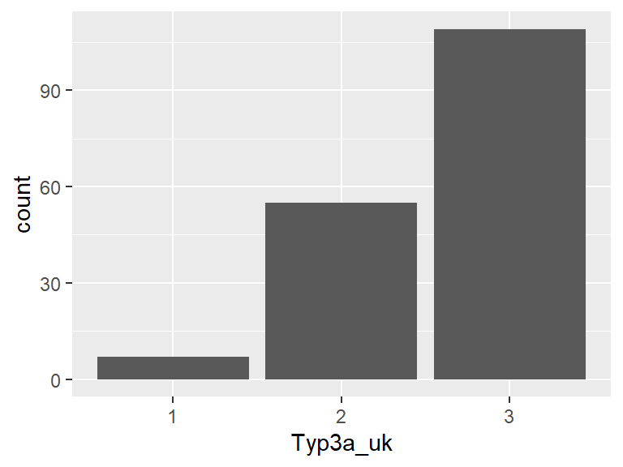

## Typ3a_mn

*Månedlig: Ant dager drukket brennevin siste 4 uker?*

| Feature | Result |
| --- | --- |
| Variable type | factor |
| Number of missing obs. | 3560 (77.16 %) |
| Number of unique values | 5 |
| Mode | “3” |
| Reference category | 1 |

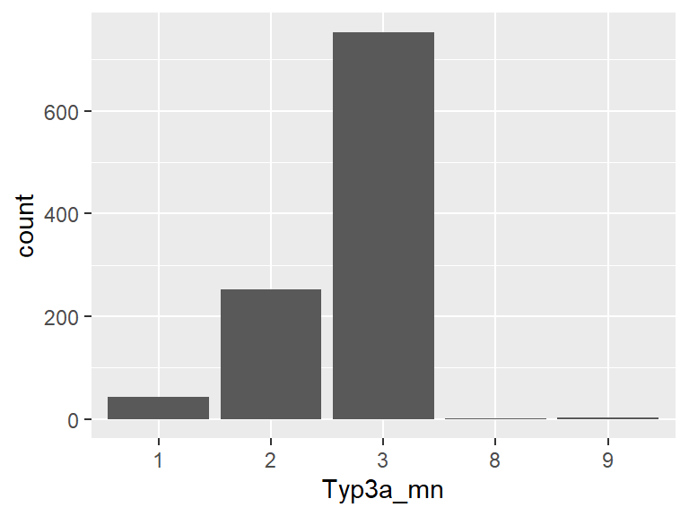

- The following suspected missing value codes enter as regular values: "8", "9".
- Note that the following levels have at most five observations: "8", "9".

## Type3b_a

*Ukentlig: Drukket drammer siste 4 uker*

| Feature | Result |
| --- | --- |
| Variable type | factor |
| Number of missing obs. | 4438 (96.19 %) |
| Number of unique values | 3 |
| Mode | “1” |
| Reference category | 1 |

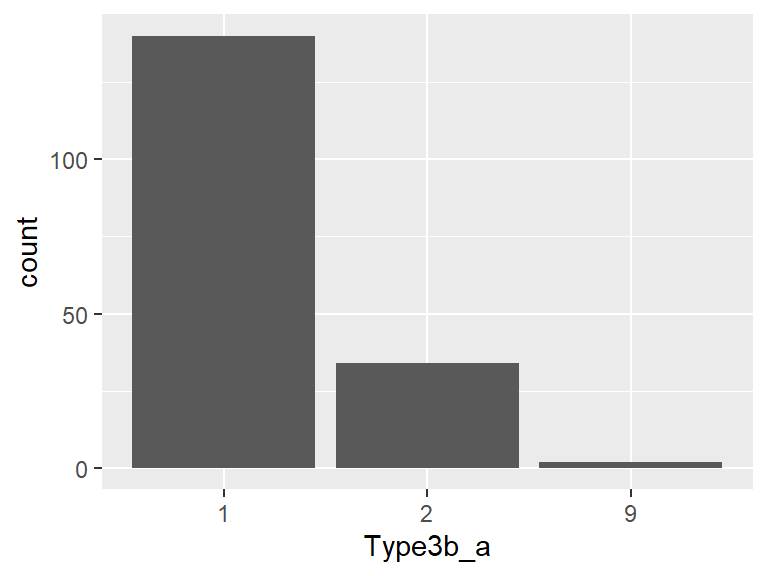

- The following suspected missing value codes enter as regular values: "9".
- Note that the following levels have at most five observations: "9".

## Type3b_b

*Ukentlig: Drukket flasker sprit siste 4 uker*

| Feature | Result |
| --- | --- |
| Variable type | factor |
| Number of missing obs. | 4438 (96.19 %) |
| Number of unique values | 3 |
| Mode | “2” |
| Reference category | 1 |

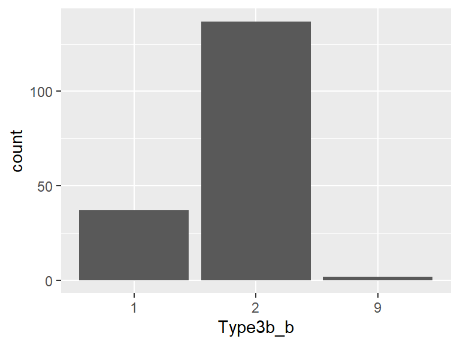

- The following suspected missing value codes enter as regular values: "9".
- Note that the following levels have at most five observations: "9".

## Type3b_1

*Ukentlig: Gjennomsnitt antall glass drammer drukket siste 4 uker?*

| Feature | Result |
| --- | --- |
| Variable type | numeric |
| Number of missing obs. | 4474 (96.97 %) |
| Number of unique values | 18 |
| Median | 4 |
| 1st and 3rd quartiles | 2; 6 |
| Min. and max. | 0.2; 30 |

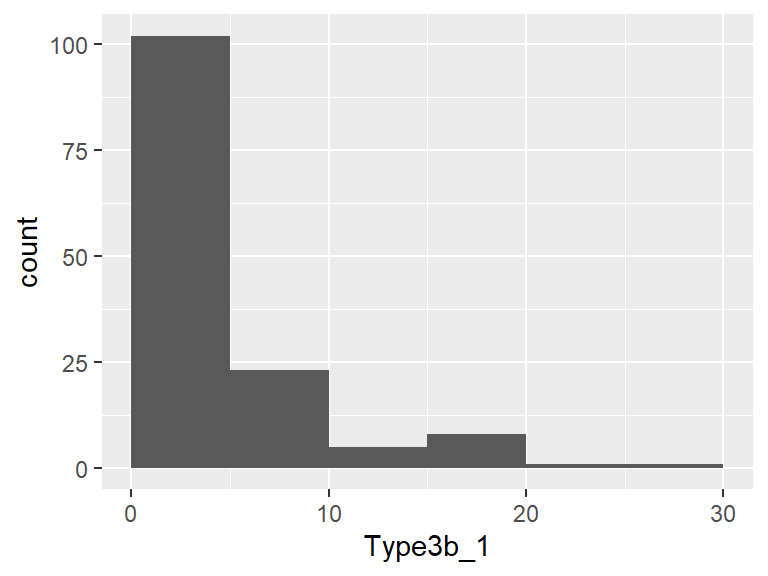

- Note that the following possible outlier values were detected: "17", "18", "20", "25", "30".

## Type3b_2

*Ukentlig: Gjennomsnitt antall helflasker sprit drukket siste 4 uker?*

| Feature | Result |
| --- | --- |
| Variable type | numeric |
| Number of missing obs. | 4577 (99.2 %) |
| Number of unique values | 10 |
| Median | 1 |
| 1st and 3rd quartiles | 0.5; 2 |
| Min. and max. | 0.2; 7 |

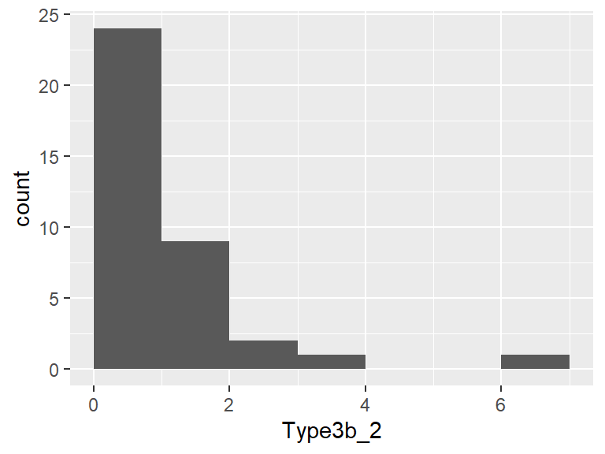

## Type3c_a

*Månedlig: Drukket drammer siste 4 uker*

| Feature | Result |
| --- | --- |
| Variable type | factor |
| Number of missing obs. | 3562 (77.2 %) |
| Number of unique values | 3 |
| Mode | “1” |
| Reference category | 1 |

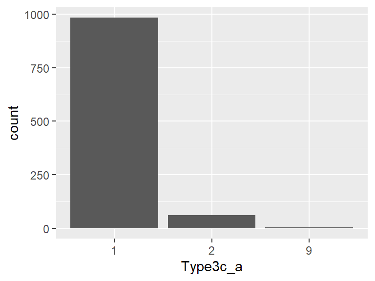

- The following suspected missing value codes enter as regular values: "9".
- Note that the following levels have at most five observations: "9".

## Type3c_b

*Månedlig: Drukket flasker sprit siste 4 uker*

| Feature | Result |
| --- | --- |
| Variable type | factor |
| Number of missing obs. | 3562 (77.2 %) |
| Number of unique values | 3 |
| Mode | “2” |
| Reference category | 1 |

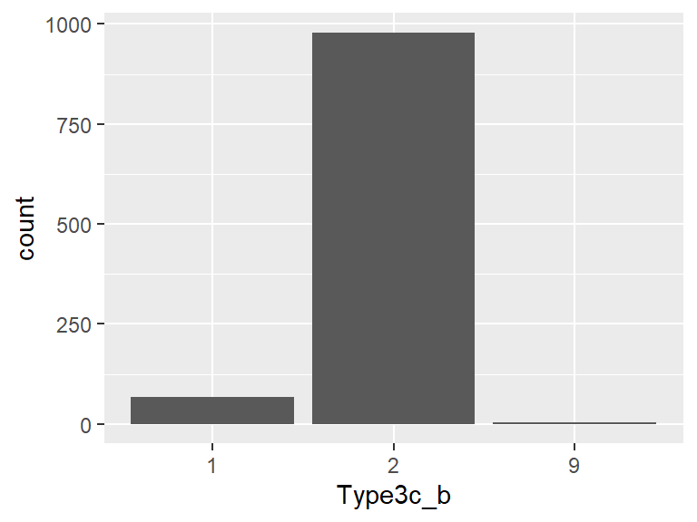

- The following suspected missing value codes enter as regular values: "9".
- Note that the following levels have at most five observations: "9".

## Type3c_1

*Månedlig: Antall drammer drukket siste 4 uker?*

| Feature | Result |
| --- | --- |
| Variable type | numeric |
| Number of missing obs. | 3629 (78.65 %) |
| Number of unique values | 22 |
| Median | 3 |
| 1st and 3rd quartiles | 2; 5 |
| Min. and max. | 0.1; 99999 |

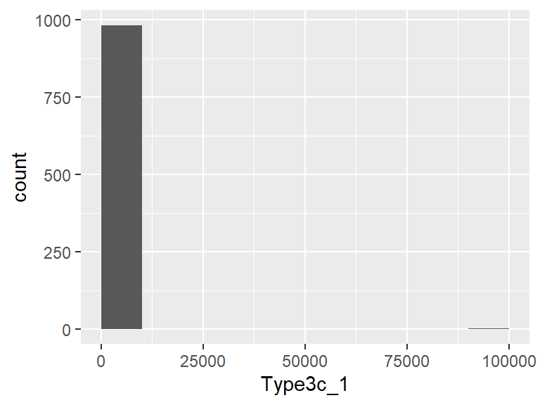

- The following suspected missing value codes enter as regular values: "99999".
- Note that the following possible outlier values were detected: "0.1", "0.5", "18", "20", "22", "200", "99999".

## Type3c_2

*Månedlig: Antall flasker sprit drukket siste 4 uker?*

| Feature | Result |
| --- | --- |
| Variable type | numeric |
| Number of missing obs. | 4546 (98.53 %) |
| Number of unique values | 14 |
| Median | 1 |
| 1st and 3rd quartiles | 1; 1.5 |
| Min. and max. | 0.1; 99999 |

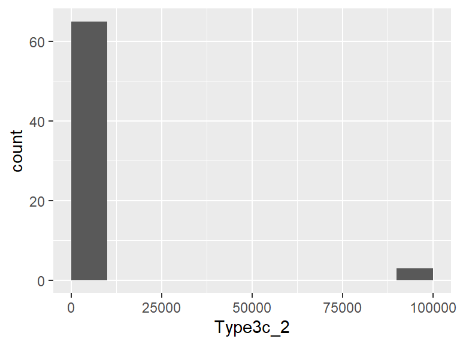

- The following suspected missing value codes enter as regular values: "99999".
- Note that the following possible outlier values were detected: "0.1", "0.2", "0.3", "0.5", "0.8", "10", "99999".

## Type4a

*Hvor ofte drukket rusbrus siste 4 uker?*

| Feature | Result |
| --- | --- |
| Variable type | factor |
| Number of missing obs. | 3669 (79.52 %) |
| Number of unique values | 4 |
| Mode | “3” |
| Reference category | 1 |

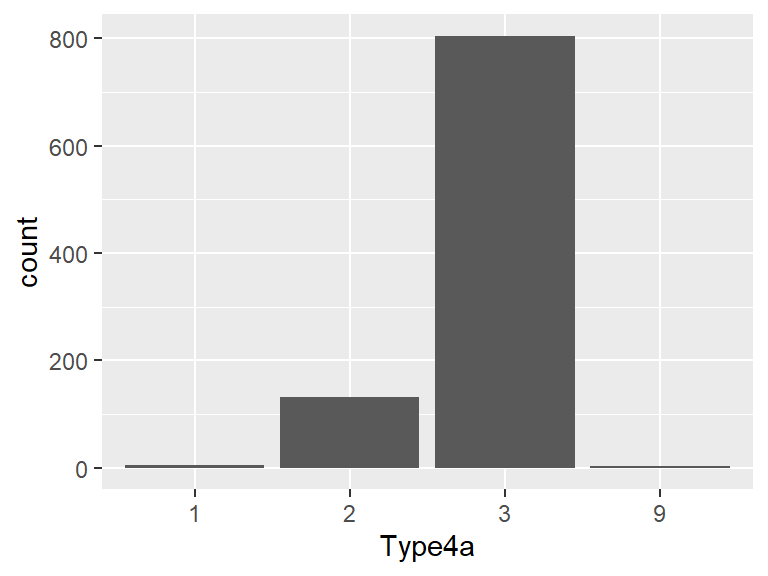

- The following suspected missing value codes enter as regular values: "9".
- Note that the following levels have at most five observations: "1", "9".

## Typ4a_uk

*Ukentlig: Ant dager i uken drukket rusbrus/alkoholholdig cider siste 4 uker?*

| Feature | Result |
| --- | --- |
| Variable type | factor |
| Number of missing obs. | 4482 (97.14 %) |
| Number of unique values | 4 |
| Mode | “3” |
| Reference category | 1 |

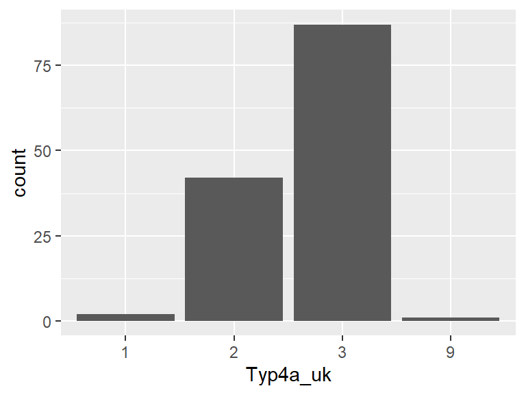

- The following suspected missing value codes enter as regular values: "9".
- Note that the following levels have at most five observations: "1", "9".

## Typ4a_mn

*Månedlig: Ant dager i uken drukket rusbrus/alkoholholdig cider siste 4 uker?*

| Feature | Result |
| --- | --- |
| Variable type | factor |
| Number of missing obs. | 3809 (82.55 %) |
| Number of unique values | 5 |
| Mode | “3” |
| Reference category | 1 |

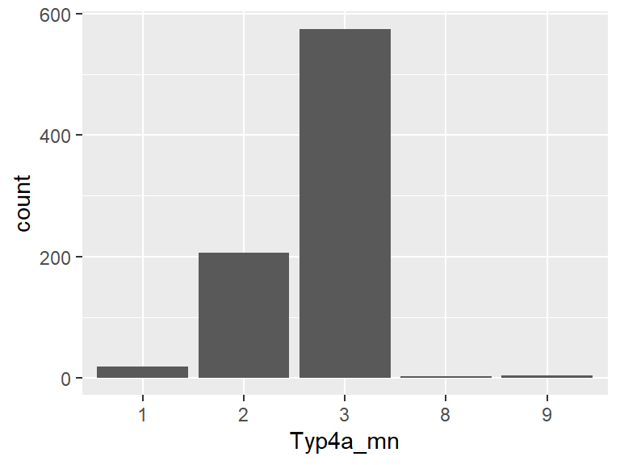

- The following suspected missing value codes enter as regular values: "8", "9".
- Note that the following levels have at most five observations: "8", "9".

## Type4b_a

*Ukentlig: Drukket småflasker/småbokser siste 4 uker*

| Feature | Result |
| --- | --- |
| Variable type | factor |
| Number of missing obs. | 4477 (97.03 %) |
| Number of unique values | 3 |
| Mode | “1” |
| Reference category | 1 |

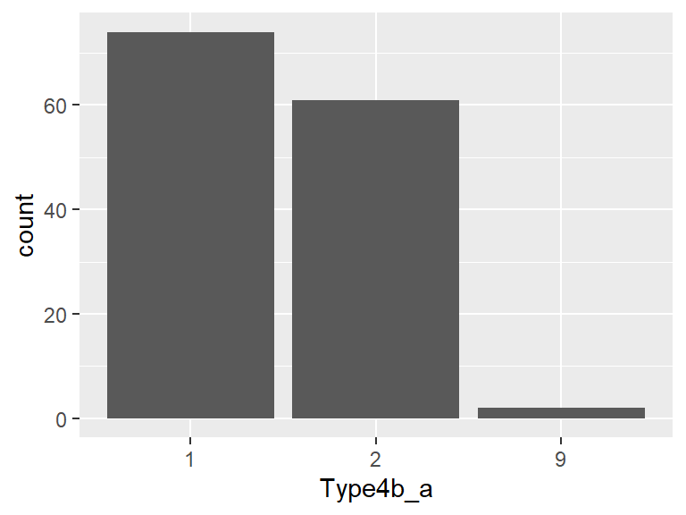

- The following suspected missing value codes enter as regular values: "9".
- Note that the following levels have at most five observations: "9".

## Type4b_b

*Ukentlig: Drukket 0,5 liter siste 4 uker*

| Feature | Result |
| --- | --- |
| Variable type | factor |
| Number of missing obs. | 4477 (97.03 %) |
| Number of unique values | 3 |
| Mode | “2” |
| Reference category | 1 |

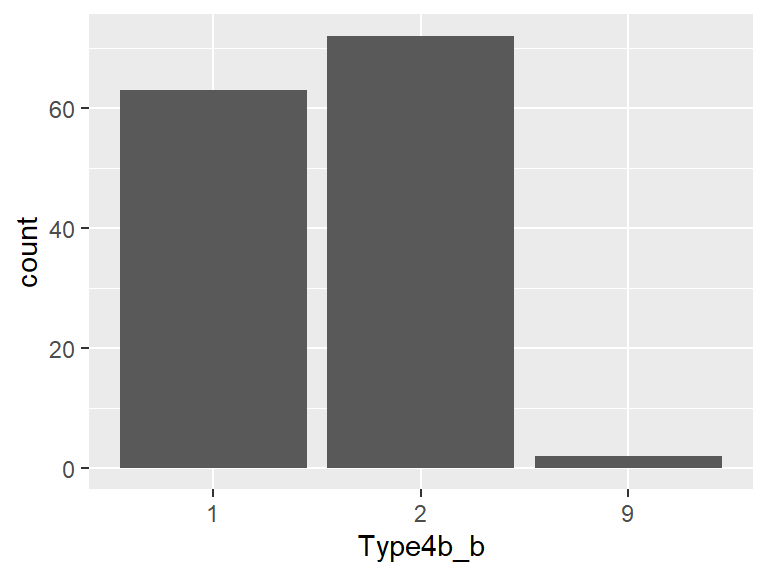

- The following suspected missing value codes enter as regular values: "9".
- Note that the following levels have at most five observations: "9".

## Type4b_1

*Ukentlig: Gjennomsnitt antall småflasker rusbrus/cider drukket siste 4 uker?*

| Feature | Result |
| --- | --- |
| Variable type | numeric |
| Number of missing obs. | 4540 (98.4 %) |
| Number of unique values | 16 |
| Median | 3 |
| 1st and 3rd quartiles | 2; 6 |
| Min. and max. | 0.5; 70 |

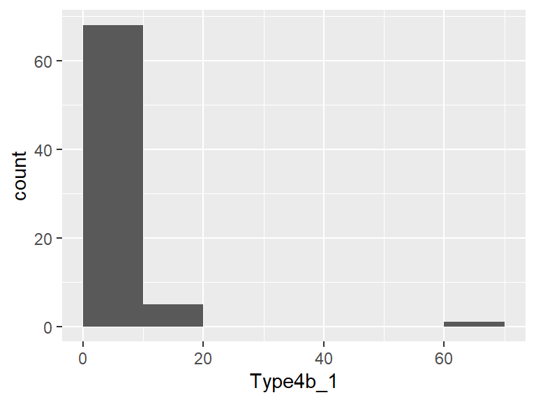

- Note that the following possible outlier values were detected: "0.5", "0.7", "1", "70".

## Type4b_2

*Ukentlig: Gjennomsnitt antall halvliter rusbrus/cider drukket siste 4 uker?*

| Feature | Result |
| --- | --- |
| Variable type | numeric |
| Number of missing obs. | 4551 (98.63 %) |
| Number of unique values | 14 |
| Median | 3 |
| 1st and 3rd quartiles | 2; 5 |
| Min. and max. | 0.5; 40 |

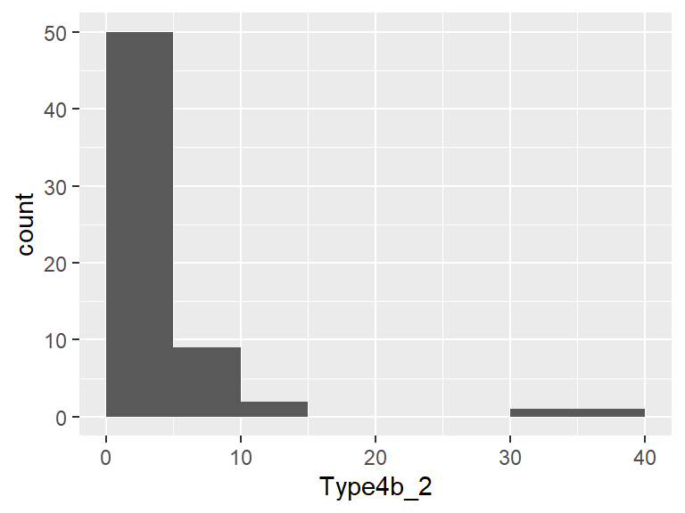

- Note that the following possible outlier values were detected: "0.5", "35", "40".